# Crime

datadavidz

January 24, 2017

## Analysis of Motor Vehicle Theft in Chicago

A subset of criminal data recorded by the FBI is analyzed in this report. The data is for motor vehicle thefts in Chicago from 2001 to 2012. A description of the variables follows:

- **ID:** a unique identifier for each observation
- **Date:** the date the crime occurred
- **LocationDescription:** the location where the crime occurred
- **Arrest:** whether or not an arrest was made for the crime (TRUE if an arrest was made and FALSE if no arrest made)
- **Domestic:** whether or not the crime was a domestic crime meaning that it was committed against a family member (TRUE if it was domestic and FALSE if it was not domestic)
- **Beat:** the area or “beat” in which the crime occurred. This is the smallest regional division defined by the Chicago police department
- **District:** the police district in which the crime occurred. Each district is composed of many beats and are defined by the Chicago Police Department.
- **CommunityArea:** the community area in which the crime occurred. Since the 1920s, Chicago has been divided into what are called “community areas” of which there are now 77. The community areas were devised in an attempt to create socially homogeneous regions.
- **Year:** the year in which the crime occurred
- **Latitude:** the latitude of the location at which the crime occurred
- **Longitude:** the longitude of the location at which the crime occurred

### Loading the Data

Read the dataset mvtWeek1.csv into a dataframe called “mvt”.

```r
setwd("~/Crime")
mvt <- read.csv("mvtWeek1.csv")
```

### Display str information

```r
str(mvt)
```

```
## 'data.frame':    191641 obs. of  11 variables:
##  $ ID                 : int  8951354 8951141 8952745 8952223 8951608 8950793 8950760 8951611 8951802 8950706 ...
##  $ Date               : Factor w/ 131680 levels "1/1/01 0:01",..: 42824 42823 42823 42823 42822 42821 42820 42819 42817 42816 ...
##  $ LocationDescription: Factor w/ 78 levels "ABANDONED BUILDING",..: 72 72 62 72 72 72 72 72 72 72 ...
##  $ Arrest             : logi  FALSE FALSE FALSE FALSE FALSE TRUE ...
##  $ Domestic           : logi  FALSE FALSE FALSE FALSE FALSE FALSE ...
##  $ Beat               : int  623 1213 1622 724 211 2521 423 231 1021 1215 ...
##  $ District           : int  6 12 16 7 2 25 4 2 10 12 ...
##  $ CommunityArea      : int  69 24 11 67 35 19 48 40 29 24 ...
##  $ Year               : int  2012 2012 2012 2012 2012 2012 2012 2012 2012 2012 ...
##  $ Latitude           : num  41.8 41.9 42 41.8 41.8 ...
##  $ Longitude          : num  -87.6 -87.7 -87.8 -87.7 -87.6 ...
```

### Exploring the data variables

The maximum ID number is 9181151.

```r
max(mvt$ID)
```

```
## [1] 9181151
```

```r
min(mvt$Beat)
```

```
## [1] 111
```

```r
sum(mvt$Arrest == TRUE)
```

```
## [1] 15536
```

```r
sum(mvt$LocationDescription == "ALLEY")
```

```
## [1] 2308
```

### Make the date variable an R date

The dates are in Month/Day/Year Hour:Minute format. For example, the first date entry is 12/31/12 23:15.

```r
DateConvert = as.Date(strptime(mvt$Date, "%m/%d/%y %H:%M"))
median(DateConvert)
```

```
## [1] "2006-05-21"
```

```r
#Extract Month and Day and add to mvt dataframe
mvt$Month <- months(DateConvert)
mvt$Day <- weekdays(DateConvert)
#Replace original date variable with converted dates
mvt$Date <- DateConvert
```

Motor vehicle crimes by month:

```r
table(mvt$Month)
```

```
##
##     April    August  December  February   January      July      June
##     15280     16572     16426     13511     16047     16801     16002
##     March       May  November   October September
##     15758     16035     16063     17086     16060
```

The month with the fewest motor vehicle thefts was February.

Motor vehicle thefts by weekday:

```r
table(mvt$Day)
```

```
##
##    Friday    Monday  Saturday    Sunday  Thursday   Tuesday Wednesday
##     29284     27397     27118     26316     27319     26791     27416
```

The weekday with the most motor vehicle thefts was Friday.

# Visualizing the dataset

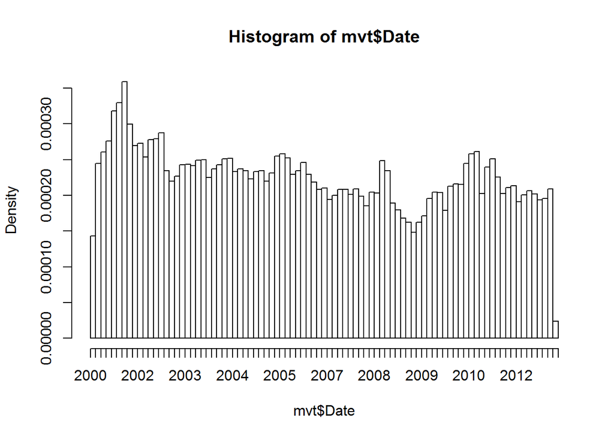

```r
hist(mvt$Date, breaks=100)
```

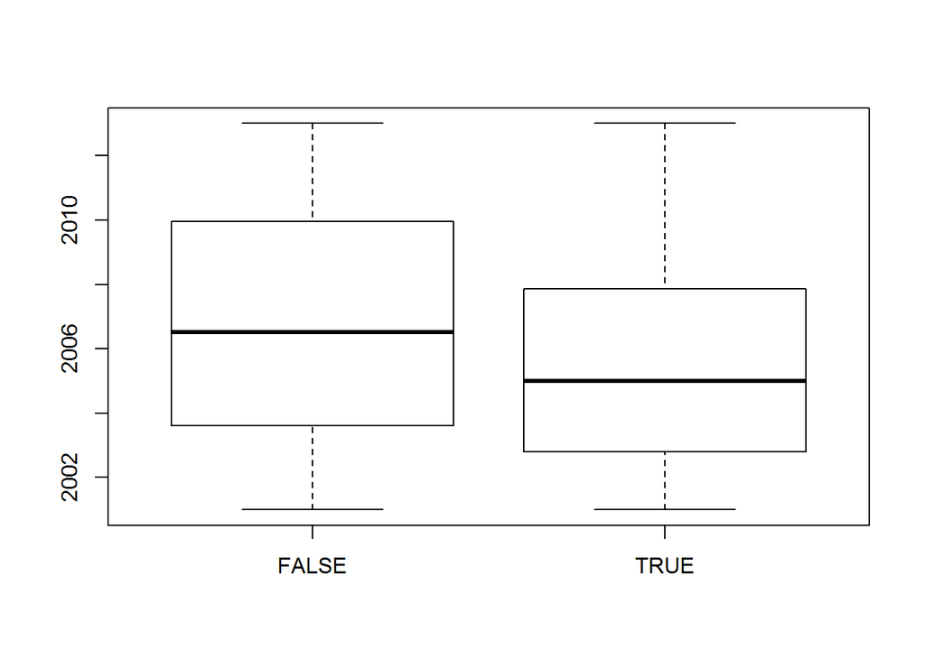

```r
boxplot(mvt$Date ~ mvt$Arrest)
```

More arrests appear to be occurring in the beginning of the time period.

Table of Crimes with and without Arrest by Year

```r
table(mvt$Year, mvt$Arrest)
```

```
##
##        FALSE  TRUE
##   2001 18517  2152
##   2002 16638  2115
##   2003 14859  1798
##   2004 15169  1693
##   2005 14956  1528
##   2006 14796  1302
##   2007 13068  1212
##   2008 13425  1020
##   2009 11327   840
##   2010 14796   701
##   2011 15012   625
##   2012 13542   550
```

The proportion of crimes with arrest made in 2001 was 0.1041173. The proportion of crimes with arrest made in 2007 was 0.0848739.

Table of Motor Vehicle Thefts by Location

```r
sort(table(mvt$LocationDescription))
```

```
##
##     AIRPORT BUILDING NON-TERMINAL - SECURE AREA
##                                               1
##                  AIRPORT EXTERIOR - SECURE AREA
##                                               1
##                                 ANIMAL HOSPITAL
##                                               1
##                                 APPLIANCE STORE
##                                               1
##                                       CTA TRAIN
##                                               1
##                         JAIL / LOCK-UP FACILITY
##                                               1
##                                       NEWSSTAND
##                                               1
##                                          BRIDGE
##                                               2
##               COLLEGE/UNIVERSITY RESIDENCE HALL
##                                               2
##                               CURRENCY EXCHANGE
##                                               2
##                                   BOWLING ALLEY
##                                               3
##                                  CLEANING STORE
##                                               3
##                           MEDICAL/DENTAL OFFICE
##                                               3
##                              ABANDONED BUILDING
##                                               4
## AIRPORT BUILDING NON-TERMINAL - NON-SECURE AREA
##                                               4
##                                      BARBERSHOP
##                                               4
##                  LAKEFRONT/WATERFRONT/RIVERBANK
##                                               4
##                                         LIBRARY
##                                               4
##                                SAVINGS AND LOAN
##                                               4
##  AIRPORT TERMINAL UPPER LEVEL - NON-SECURE AREA
```

[output cut: 102 more lines]

```
##                                            1302
##                   RESIDENTIAL YARD (FRONT/BACK)
##                                            1536
##                          DRIVEWAY - RESIDENTIAL
##                                            1675
##                                     GAS STATION
##                                            2111
##                                           ALLEY
##                                            2308
##                                           OTHER
##                                            4573
##                  PARKING LOT/GARAGE(NON.RESID.)
##                                           14852
##                                          STREET
##                                          156564
```

```r
topLocations <- c("STREET", "PARKING LOT/GARAGE(NON.RESID.)", "ALLEY", "GAS STATION", "DRIVEWAY - RESIDENTIAL")
top5 <- subset(mvt, LocationDescription %in% topLocations)

# Remove the unused factor variables from LocationDescription
top5$LocationDescription <- factor(top5$LocationDescription)
```

Table of Arrests for Top 5 Locations

```r
table(top5$LocationDescription, top5$Arrest)
```

```
##
##                                   FALSE   TRUE
##   ALLEY                            2059    249
##   DRIVEWAY - RESIDENTIAL           1543    132
##   GAS STATION                      1672    439
##   PARKING LOT/GARAGE(NON.RESID.)  13249   1603
##   STREET                         144969  11595
```

Arrest rate at GAS STATION is highest 0.2079583.

Table of Motor Vehicle Thefts by Weekday

```r
table(top5$LocationDescription, top5$Day)
```

```
##
##                                  Friday Monday Saturday Sunday Thursday
##   ALLEY                             385    320      341    307      315
##   DRIVEWAY - RESIDENTIAL            257    255      202    221      263
##   GAS STATION                       332    280      338    336      282
##   PARKING LOT/GARAGE(NON.RESID.)   2331   2128     2199   1936     2082
##   STREET                          23773  22305    22175  21756    22296
##
##                                  Tuesday Wednesday
##   ALLEY                              323       317
##   DRIVEWAY - RESIDENTIAL             243       234
##   GAS STATION                        270       273
##   PARKING LOT/GARAGE(NON.RESID.)    2073      2103
##   STREET                           21888     22371
```

The most motor vehicle thefts at GAS STATION happen on Saturday. The fewest motor vehicle thefts at DRIVEWAY - RESIDENTIAL happen on Saturday.